# Tugas 1 — Pengantar Analisis Data Kategori

Latihan Analisis Data dengan R dan Quarto

[output not shown]

```r
# Tulis kode Anda di sini
# Melihat 6 baris pertama data
head(data)
```

```
  RecordID     ProgramStudi Gender DeviceUtama ModaBelajar    Kepuasan
1   817459 Sistem Informasi      P      Tablet        Buku       Cukup
2   777103       Sains Data      L      Laptop       Video        Puas
3   815045   Sains Aktuaria      L  Smartphone        Buku Sangat Puas
4   126221 Sistem Informasi      L  Smartphone       Video        Puas
5   625417   Sains Aktuaria      L      Laptop     Praktik        Puas
6   849475   Sains Aktuaria      L      Tablet     Praktik        Puas
  IntensitasBelajar DurasiBelajarJam       PaketID
1            Sedang              7.1 ADK1-070182B9
2            Sedang              8.5 ADK1-070182B9
3            Sedang              8.0 ADK1-070182B9
4            Rendah              4.5 ADK1-070182B9
5            Tinggi             11.1 ADK1-070182B9
6            Sedang              4.8 ADK1-070182B9
```

```r
# Melihat struktur data
str(data)
```

```
'data.frame':   112 obs. of  9 variables:
 $ RecordID         : int  817459 777103 815045 126221 625417 849475 962902 379550 268458 899415 ...
 $ ProgramStudi     : chr  "Sistem Informasi" "Sains Data" "Sains Aktuaria" "Sistem Informasi" ...
 $ Gender           : chr  "P" "L" "L" "L" ...
 $ DeviceUtama      : chr  "Tablet" "Laptop" "Smartphone" "Smartphone" ...
 $ ModaBelajar      : chr  "Buku" "Video" "Buku" "Video" ...
 $ Kepuasan         : chr  "Cukup" "Puas" "Sangat Puas" "Puas" ...
 $ IntensitasBelajar: chr  "Sedang" "Sedang" "Sedang" "Rendah" ...
 $ DurasiBelajarJam : num  7.1 8.5 8 4.5 11.1 4.8 5 11.2 7.1 7.7 ...
 $ PaketID          : chr  "ADK1-070182B9" "ADK1-070182B9" "ADK1-070182B9" "ADK1-070182B9" ...
```

```r
# Melihat nama-nama variabel
names(data)
```

```
[1] "RecordID"          "ProgramStudi"      "Gender"
[4] "DeviceUtama"       "ModaBelajar"       "Kepuasan"
[7] "IntensitasBelajar" "DurasiBelajarJam"  "PaketID"
```

Lengkapi tabel berikut.

| Variabel | Jenis Variabel | Alasan Singkat |
| --- | --- | --- |
| RecordID | Identifier | Digunakan sebagai identitas unik setiap record |
| ProgramStudi | Nominal | Berupa kategori program studi dan tidak memiliki urutan |
| Gender | Nominal | Berupa kategori dan tidak memiliki tingkatan |
| DeviceUtama | Nominal | Menunjukkan jenis perangkat dan tidak memiliki urutan |
| ModaBelajar | Nominal | Menunjukkan kategori moda belajar tanpa tingkatan |
| Kepuasan | Ordinal | Memiliki kategori yang dapat diurutkan berdasarkan tingkat kepuasan |
| IntensitasBelajar | Ordinal | Memiliki tingkatan yang dapat diurutkan dari rendah ke tinggi |
| DurasiBelajarJam | Numerik | Menunjukkan lama waktu belajar yang dapat diukur dalam angka |

Jawab singkat:

1. Variabel mana yang merupakan identifier?
2. Variabel mana yang bersifat ordinal?
3. Mengapa kode angka belum tentu berarti data numerik?

**Jawaban Anda**

1. Variabel identifier adalah **RecordID**, karena hanya berfungsi sebagai penanda unik tiap baris data dan tidak dianalisis sebagai kategori.
2. Variabel ordinal adalah **Kepuasan** dan **IntensitasBelajar**, karena kategorinya memiliki tingkatan yang dapat diurutkan.
3. Kode angka (misalnya 1, 2, 3) sering hanya menjadi label untuk kategori, sehingga jarak dan operasi hitung antar angkanya (seperti rata-rata) tidak bermakna. Angka tersebut tetap data kategori, bukan numerik.

# 1 2. Menyiapkan Data Kategori

Variabel latihan Anda:

```r
cat("Nominal :", identitas$nominal_utama[1], "\n")
```

```
Nominal : ModaBelajar
```

```r
cat("Ordinal :", identitas$ordinal_utama[1], "\n")
```

```
Ordinal : IntensitasBelajar
```

```r
cat("Urutan  :", identitas$urutan_ordinal[1], "\n")
```

```
Urutan  : Rendah|Sedang|Tinggi
```

Lakukan hal berikut:

1. ubah variabel nominal menjadi factor;
2. ubah variabel ordinal menjadi ordered factor;
3. periksa level kategorinya.

**TipPetunjuk kode**

Untuk nominal:

```r
factor(...)
levels(...)
```

Untuk ordinal:

```r
factor(..., levels = ..., ordered = TRUE)
```

```r
nominal_var <- identitas$nominal_utama[1]
ordinal_var <- identitas$ordinal_utama[1]
urutan <- trimws(strsplit(identitas$urutan_ordinal[1], "\\|")[[1]])

# Tulis kode Anda di bawah ini
print(names(data))
```

```
[1] "RecordID"          "ProgramStudi"      "Gender"
[4] "DeviceUtama"       "ModaBelajar"       "Kepuasan"
[7] "IntensitasBelajar" "DurasiBelajarJam"  "PaketID"
```

```r
print(nominal_var)
```

```
[1] "ModaBelajar"
```

```r
print(ordinal_var)
```

```
[1] "IntensitasBelajar"
```

```r
# 1. Ubah variabel nominal menjadi factor
data[[nominal_var]] <- factor(data[[nominal_var]])

# 2. Ubah variabel ordinal menjadi ordered factor
data[[ordinal_var]] <- factor(
  data[[ordinal_var]],
  levels = urutan,
  ordered = TRUE
)

# 3. Periksa level kategorinya
levels(data[[nominal_var]])
```

```
[1] "Buku"    "Diskusi" "Praktik" "Video"
```

```r
levels(data[[ordinal_var]])
```

```
[1] "Rendah" "Sedang" "Tinggi"
```

```r
is.ordered(data[[ordinal_var]])
```

```
[1] TRUE
```

Tuliskan satu kalimat: **mengapa urutan level ordinal perlu ditetapkan dengan benar?**

**Jawaban Anda**

Urutan level ordinal perlu ditetapkan dengan benar agar R membaca kategori sesuai tingkatannya (Rendah < Sedang < Tinggi), bukan berdasarkan urutan abjad, sehingga tabel dan grafik tersusun dengan benar.

# 2 3. Quality Control Awal

Lakukan pemeriksaan sederhana terhadap:

- struktur data;
- level/kategori;
- missing value;
- konsistensi penulisan kategori.

**TipPetunjuk kode**

Beberapa pola fungsi yang dapat digunakan:

```r
str(...)
levels(...)
unique(...)
is.na(...)
colSums(...)
```

Pilih fungsi yang sesuai dengan tujuan pemeriksaan Anda.

```r
# Tulis kode Anda di sini
# Melihat struktur data
str(data)
```

```
'data.frame':   112 obs. of  9 variables:
 $ RecordID         : int  817459 777103 815045 126221 625417 849475 962902 379550 268458 899415 ...
 $ ProgramStudi     : chr  "Sistem Informasi" "Sains Data" "Sains Aktuaria" "Sistem Informasi" ...
 $ Gender           : chr  "P" "L" "L" "L" ...
 $ DeviceUtama      : chr  "Tablet" "Laptop" "Smartphone" "Smartphone" ...
 $ ModaBelajar      : Factor w/ 4 levels "Buku","Diskusi",..: 1 4 1 4 3 3 3 2 1 4 ...
 $ Kepuasan         : chr  "Cukup" "Puas" "Sangat Puas" "Puas" ...
 $ IntensitasBelajar: Ord.factor w/ 3 levels "Rendah"<"Sedang"<..: 2 2 2 1 3 2 2 3 1 2 ...
 $ DurasiBelajarJam : num  7.1 8.5 8 4.5 11.1 4.8 5 11.2 7.1 7.7 ...
 $ PaketID          : chr  "ADK1-070182B9" "ADK1-070182B9" "ADK1-070182B9" "ADK1-070182B9" ...
```

```r
# Melihat kategori pada variabel kategorik
levels(data[[nominal_var]])
```

```
[1] "Buku"    "Diskusi" "Praktik" "Video"
```

```r
levels(data[[ordinal_var]])
```

```
[1] "Rendah" "Sedang" "Tinggi"
```

```r
# Melihat nilai unik setiap variabel
lapply(data, unique)
```

```
$RecordID
  [1] 817459 777103 815045 126221 625417 849475 962902 379550 268458 899415
 [11] 237199 685260 359807 413032 340439 613508 142328 796431 655208 659682
 [21] 274306 557045 953438 864313 843547 717677 183535 707362 971189 696256
 [31] 866088 685752 817480 901906 584331 138344 341431 467259 940932 347337
 [41] 932454 983785 767816 246654 520878 866308 463705 948498 543688 331810
 [51] 765033 334488 658185 172058 723889 784171 894378 814739 812248 451650
 [61] 605574 266526 664849 787756 279048 840371 453560 227700 880259 966061
 [71] 534514 601993 371263 850214 693725 112472 481986 456006 174229 606528
 [81] 811272 236730 367392 341258 968951 506671 383848 622832 177975 707626
 [91] 430333 567209 712601 510721 865771 645643 168693 894012 786541 719800
[101] 197615 501493 738326 828283 972445 435377 171263 418328 221982 585871
[111] 810860 261471

$ProgramStudi
[1] "Sistem Informasi" "Sains Data"       "Sains Aktuaria"   "Matematika"

$Gender
[1] "P" "L"

$DeviceUtama
[1] "Tablet"     "Laptop"     "Smartphone" NA

$ModaBelajar
[1] Buku    Video   Praktik Diskusi
Levels: Buku Diskusi Praktik Video

$Kepuasan
[1] "Cukup"       "Puas"        "Sangat Puas" "Tidak Puas"

$IntensitasBelajar
[1] Sedang Rendah Tinggi
Levels: Rendah < Sedang < Tinggi

$DurasiBelajarJam
 [1]  7.1  8.5  8.0  4.5 11.1  4.8  5.0 11.2  7.7  8.3   NA 10.4 11.3  6.6 12.6
[16]  7.6  4.0  7.9  9.4  1.2  9.9  5.3  9.7 10.5  6.3  3.0  4.9  2.1  3.6  2.5
[31] 12.8  6.0  7.2  8.6 12.0  6.9  4.7 12.4  8.2  7.5  6.7 11.0  5.6  4.2  3.2
[46] 10.7  9.8 10.6  4.3  3.4  8.9  9.1  6.4 10.3  5.8  7.4  9.6  8.8  8.1  5.7
[61]  4.4  5.4 10.1 13.2 10.9  5.1 10.8  7.0 14.3 11.4 12.3

$PaketID
[1] "ADK1-070182B9"
```

```r
# Mengecek missing value setiap variabel
colSums(is.na(data))
```

```
         RecordID      ProgramStudi            Gender       DeviceUtama
                0                 0                 0                 3
      ModaBelajar          Kepuasan IntensitasBelajar  DurasiBelajarJam
                0                 0                 0                 1
          PaketID
                0
```

```r
# Mengecek konsistensi penulisan kategori
lapply(data[sapply(data, function(x) is.character(x) || is.factor(x))], unique)
```

```
$ProgramStudi
[1] "Sistem Informasi" "Sains Data"       "Sains Aktuaria"   "Matematika"

$Gender
[1] "P" "L"

$DeviceUtama
[1] "Tablet"     "Laptop"     "Smartphone" NA

$ModaBelajar
[1] Buku    Video   Praktik Diskusi
Levels: Buku Diskusi Praktik Video

$Kepuasan
[1] "Cukup"       "Puas"        "Sangat Puas" "Tidak Puas"

$IntensitasBelajar
[1] Sedang Rendah Tinggi
Levels: Rendah < Sedang < Tinggi

$PaketID
[1] "ADK1-070182B9"
```

Tuliskan **dua temuan singkat** dari pemeriksaan tersebut.

**Jawaban Anda**

1. Data terdiri dari 112 baris dan 9 variabel, dengan total 4 missing value pada seluruh data.
2. Variabel nominal ModaBelajar memiliki 4 kategori, sedangkan variabel ordinal IntensitasBelajar memiliki 3 level yang telah terurut (Rendah < Sedang < Tinggi).

# 3 4. Frekuensi dan Proporsi

Sebelum menjalankan kode, prediksi:

> Menurut Anda, kategori mana yang paling banyak muncul pada variabel nominal Anda?

**Prediksi Anda**

Sebelum melihat output, saya memperkirakan bahwa salah satu kategori pada variabel ModaBelajar akan muncul paling banyak dibanding kategori lainnya.

Setelah itu, buat:

- tabel frekuensi untuk variabel nominal;
- proporsi untuk variabel ordinal.

**TipPetunjuk kode**

```r
table(...)
prop.table(...)
```

Anda dapat menyimpan hasil `table()` ke sebuah objek terlebih dahulu sebelum menghitung proporsi.

```r
# Tulis kode Anda di sini
# Tabel frekuensi variabel nominal
frekuensi_nominal <- table(data[[nominal_var]])
frekuensi_nominal
```

```
   Buku Diskusi Praktik   Video
     29      22      44      17
```

```r
# Proporsi variabel ordinal
proporsi_ordinal <- prop.table(table(data[[ordinal_var]]))
proporsi_ordinal
```

```
   Rendah    Sedang    Tinggi
0.2678571 0.3571429 0.3750000
```

Tuliskan **dua kalimat insight** berdasarkan output.

**Interpretasi Anda**

1. Pada variabel ModaBelajar, kategori yang paling banyak muncul adalah **Praktik** sebanyak 44 record (39.3% dari seluruh data).
2. Pada variabel IntensitasBelajar, kategori dengan proporsi terbesar adalah **Tinggi** dengan proporsi sekitar 37.5%.

# 4 5. Tabel Silang

Pasangan variabel Anda:

```r
x <- identitas$tab_baris[1]
y <- identitas$tab_kolom[1]

cat("Baris :", x, "\n")
```

```
Baris : ModaBelajar
```

```r
cat("Kolom :", y, "\n")
```

```
Kolom : IntensitasBelajar
```

Buat tabel silang untuk kedua variabel tersebut.

Jika diperlukan, tampilkan proporsi per baris untuk membantu membaca pola.

**TipPetunjuk kode**

```r
table(..., ...)
prop.table(..., margin = 1)
```

Lengkapi sendiri objek yang diperlukan.

```r
# Tulis kode Anda di sini
# Membuat tabel silang
tabel_silang <- table(data[[x]], data[[y]])
tabel_silang
```

```
          Rendah Sedang Tinggi
  Buku        10     11      8
  Diskusi      5      9      8
  Praktik      9     11     24
  Video        6      9      2
```

```r
# Proporsi berdasarkan baris
proporsi_baris <- prop.table(tabel_silang, margin = 1)
proporsi_baris
```

```
             Rendah    Sedang    Tinggi
  Buku    0.3448276 0.3793103 0.2758621
  Diskusi 0.2272727 0.4090909 0.3636364
  Praktik 0.2045455 0.2500000 0.5454545
  Video   0.3529412 0.5294118 0.1176471
```

Tuliskan **satu kalimat** yang menjelaskan pola yang tampak.

**Interpretasi Anda**

Secara deskriptif, kombinasi yang paling sering muncul adalah **Praktik** pada ModaBelajar dengan **Tinggi** pada IntensitasBelajar sebanyak 24 record, atau sekitar 54.5% dari seluruh record pada kategori Praktik.

**Penting**

Gunakan bahasa deskriptif. Jangan langsung menyimpulkan adanya hubungan signifikan atau sebab-akibat.

# 5 6. Visualisasi Kategorik

Variabel yang divisualisasikan:

```r
v <- identitas$visualisasi[1]
cat("Variabel grafik :", v, "\n")
```

```
Variabel grafik : IntensitasBelajar
```

Buat **satu grafik batang** seperti yang telah dipelajari pada Pertemuan 1.

**TipPetunjuk kode**

```r
library(ggplot2)

ggplot(..., aes(x = ...)) +
  geom_bar() +
  labs(...)
```

Sesuaikan objek data, variabel, judul, dan label sumbu.

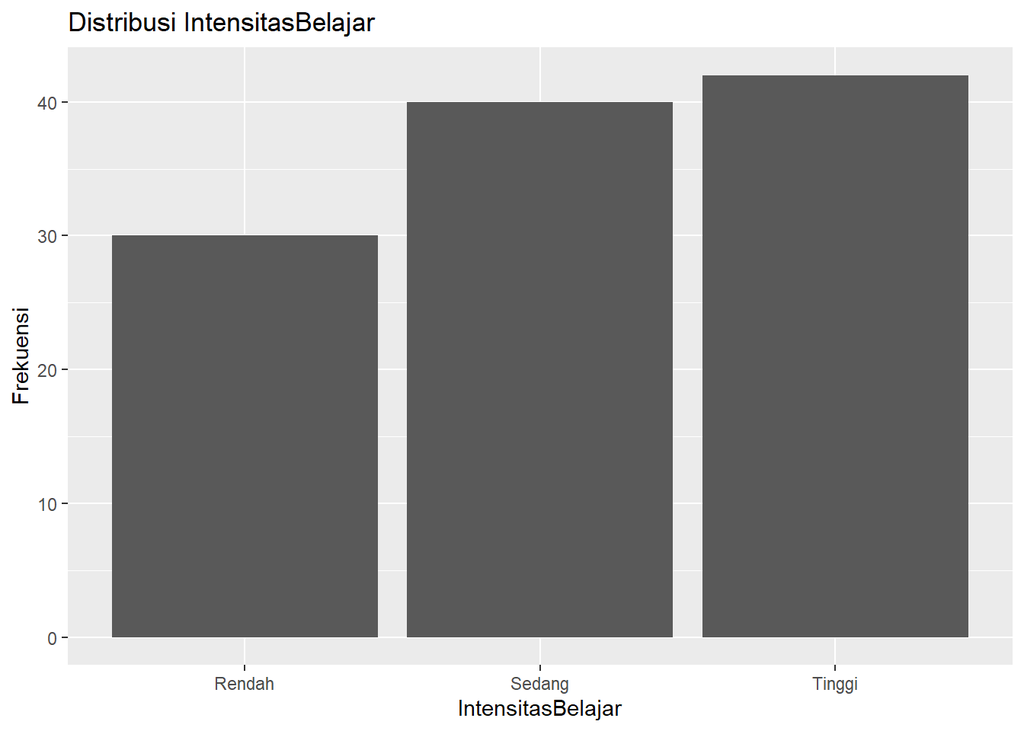

```r
# Tulis kode Anda di sini
library(ggplot2)

ggplot(data, aes(x = .data[[v]])) +
  geom_bar() +
  labs(
    title = paste("Distribusi", v),
    x = v,
    y = "Frekuensi"
  )
```

Tuliskan **satu kalimat** interpretasi grafik.

**Interpretasi Anda**

Grafik batang menunjukkan bahwa pada variabel IntensitasBelajar, kategori **Tinggi** memiliki batang tertinggi dengan frekuensi 42 record.

# 6 7. Kesimpulan

Tuliskan **3 poin kesimpulan singkat** berdasarkan hasil analisis.

Setiap kesimpulan harus:

- didukung oleh output yang telah Anda hasilkan;
- menggunakan angka yang relevan;
- ditulis dengan bahasa Anda sendiri;
- tidak menggunakan klaim sebab-akibat.

**Kesimpulan Anda**

1. Data yang dianalisis terdiri dari 112 record dan 9 variabel dengan 4 missing value, sehingga data dapat dipakai untuk ringkasan deskriptif.
2. Pada variabel ModaBelajar, kategori **Praktik** paling banyak muncul (44 record atau 39.3%), sedangkan pada variabel IntensitasBelajar kategori **Tinggi** memiliki proporsi terbesar (37.5%).
3. Pada tabel silang ModaBelajar dan IntensitasBelajar, kombinasi **Praktik** dengan **Tinggi** paling sering muncul (24 record); ini hanya gambaran pola pada data dan tidak menunjukkan hubungan signifikan maupun sebab-akibat.

**Analisis Data Kategori — Tugas 1**  
Predict → Run → Inspect → Explain